# Final Project Check Up Memo

Data Science 1 with R (STAT 301-1)

Author

Kayla Terrelonge

Published

November 20, 2022

## Demonstration of Progress

Over the past few weeks, I have began tackling my final project. However, despite outlining a detailed plan and schedule in my previous memo, I have not been able to keep up with my designated plan. This is due to the amount of time data importing has taken. To begin, the source of my data [ESPN NBA Stats section](https://www.espn.com/nba/stats) does not have an extract option for their data, meaning I had to spend a significant amount of time web scraping. The web scraping process included writing functions in google sheets to import the data into a sheet. The function used to extract the data from ESPN and import it into the sheet `=IMPORTHTML("hyperlink", "table",1)`, where the hyperlink is the link to each season’s statistics. Then, because each season’s data is under a different link, I had to create separate sheets for each season to import them with the function from above, then I had to manually merge each sheet into one cohesive data frame, as the individual sheets posed great challenges when trying to be imported to R. Then, the data frame was extracted as a `.csv` file and imported into R with the `read_delim()` function. Now, I am working on tidying the data, which should not be too much work given the amount of time I spent on the scraping process.

```r
library(tidyverse)
library(skimr)
library(readr)
```

```r
nba_reg_szn <- read_delim("data///NBA_Data_301  - nba_reg_season.csv") %>%
print()
```

```
# A tibble: 9,593 × 24
      RK Name     Season POS      GP   MIN   PTS   FGM   FGA `FG%` 3:00 …¹ `3PA`
   <dbl> <chr>    <chr>  <chr> <dbl> <dbl> <dbl> <dbl> <dbl> <dbl>   <dbl> <dbl>
 1     1 Allen I… 2001-… SG       60  43.7  31.4  11.1  27.8  39.8     1.3   4.5
 2     2 Shaquil… 2001-… C        67  36.1  27.2  10.6  18.3  57.9     0     0
 3     3 Paul Pi… 2001-… SF       82  40.3  26.1   8.6  19.5  44.2     2.6   6.3
 4     4 Tracy M… 2001-… SG       76  38.3  25.6   9.4  20.9  45.1     1.4   3.7
 5     5 Tim Dun… 2001-… C        82  40.6  25.5   9.3  18.3  50.8     0     0.1
 6     6 Kobe Br… 2001-… SF       80  38.3  25.2   9.4  20    46.9     0.4   1.7
 7     7 Vince C… 2001-… G        60  39.8  24.7   9.3  21.8  42.8     2     5.2
 8     8 Chris W… 2001-… C        54  38.4  24.5   9.9  19.9  49.5     0.1   0.4
 9     9 Dirk No… 2001-… F        76  38    23.4   7.9  16.6  47.7     1.8   4.6
10    10 Michael… 2001-… G        60  34.9  22.9   9.2  22.1  41.6     0.2   0.9
# … with 9,583 more rows, 12 more variables: `3P%` <dbl>, FTM <dbl>, FTA <dbl>,
#   `FT%` <dbl>, REB <dbl>, AST <dbl>, STL <dbl>, BLK <dbl>, TO <dbl>,
#   DD2 <dbl>, TD3 <dbl>, PER <dbl>, and abbreviated variable name ¹`3:00 PM`
```

```r
# skimming data
nba_reg_szn %>%
  skim()
```

Data summary

| Name | Piped data |
| --- | --- |
| Number of rows | 9593 |
| Number of columns | 24 |
| _______________________ |  |
| Column type frequency: |  |
| character | 3 |
| numeric | 21 |
| ________________________ |  |
| Group variables | None |

**Variable type: character**

| skim_variable | n_missing | complete_rate | min | max | empty | n_unique | whitespace |
| --- | --- | --- | --- | --- | --- | --- | --- |
| Name | 0 | 1 | 8 | 31 | 0 | 5509 | 0 |
| Season | 1 | 1 | 9 | 9 | 0 | 21 | 0 |
| POS | 10 | 1 | 1 | 2 | 0 | 8 | 0 |

**Variable type: numeric**

| skim_variable | n_missing | complete_rate | mean | sd | p0 | p25 | p50 | p75 | p100 | hist |
| --- | --- | --- | --- | --- | --- | --- | --- | --- | --- | --- |
| RK | 0 | 1.00 | 234.65 | 139.14 | 1.00 | 115.0 | 231.00 | 351.00 | 581.00 | ▇▇▇▇▁ |
| GP | 0 | 1.00 | 52.99 | 24.41 | 1.00 | 34.0 | 60.00 | 74.00 | 85.00 | ▃▃▃▆▇ |
| MIN | 0 | 1.00 | 20.55 | 9.74 | 0.70 | 12.5 | 20.10 | 28.60 | 43.70 | ▅▇▇▇▂ |
| PTS | 0 | 1.00 | 8.44 | 5.98 | 0.10 | 3.8 | 7.00 | 11.80 | 36.10 | ▇▅▂▁▁ |
| FGM | 0 | 1.00 | 3.14 | 2.17 | 0.00 | 1.4 | 2.60 | 4.40 | 12.20 | ▇▆▂▁▁ |
| FGA | 0 | 1.00 | 6.99 | 4.61 | 0.00 | 3.4 | 5.90 | 9.70 | 27.80 | ▇▆▂▁▁ |
| FG% | 0 | 1.00 | 44.30 | 8.84 | 0.00 | 40.1 | 44.00 | 48.30 | 100.00 | ▁▂▇▁▁ |
| 3:00 PM | 0 | 1.00 | 0.66 | 0.73 | 0.00 | 0.0 | 0.40 | 1.10 | 5.10 | ▇▂▁▁▁ |
| 3PA | 0 | 1.00 | 1.88 | 1.93 | 0.00 | 0.1 | 1.40 | 3.10 | 13.20 | ▇▃▁▁▁ |
| 3P% | 0 | 1.00 | 25.44 | 17.03 | 0.00 | 8.3 | 31.50 | 36.80 | 100.00 | ▅▇▂▁▁ |
| FTM | 0 | 1.00 | 1.49 | 1.40 | 0.00 | 0.5 | 1.10 | 2.00 | 10.20 | ▇▂▁▁▁ |
| FTA | 0 | 1.00 | 1.98 | 1.75 | 0.00 | 0.8 | 1.50 | 2.60 | 11.80 | ▇▂▁▁▁ |
| FT% | 0 | 1.00 | 71.16 | 18.27 | 0.00 | 65.5 | 75.00 | 82.00 | 100.00 | ▁▁▂▇▅ |
| REB | 0 | 1.00 | 3.63 | 2.46 | 0.00 | 1.9 | 3.10 | 4.80 | 16.00 | ▇▅▂▁▁ |
| AST | 200 | 0.98 | 1.82 | 1.77 | 0.00 | 0.6 | 1.20 | 2.40 | 11.70 | ▇▂▁▁▁ |
| STL | 200 | 0.98 | 0.64 | 0.43 | 0.00 | 0.3 | 0.60 | 0.90 | 2.90 | ▇▆▂▁▁ |
| BLK | 200 | 0.98 | 0.41 | 0.46 | 0.00 | 0.1 | 0.30 | 0.50 | 3.70 | ▇▁▁▁▁ |
| TO | 200 | 0.98 | 1.16 | 0.78 | 0.00 | 0.6 | 1.00 | 1.50 | 5.70 | ▇▅▁▁▁ |
| DD2 | 200 | 0.98 | 4.33 | 9.22 | 0.00 | 0.0 | 0.00 | 4.00 | 71.00 | ▇▁▁▁▁ |
| TD3 | 200 | 0.98 | 0.12 | 1.00 | 0.00 | 0.0 | 0.00 | 0.00 | 42.00 | ▇▁▁▁▁ |
| PER | 201 | 0.98 | 12.47 | 6.39 | -16.69 | 9.4 | 12.58 | 15.88 | 133.95 | ▇▆▁▁▁ |

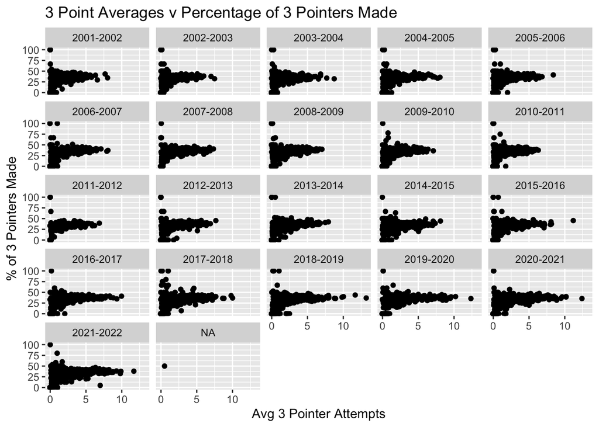

```r
# simple plot
nba_reg_szn %>%
  ggplot(mapping = aes(x = `3PA`, y = `3P%`)) +
  geom_jitter() +
  facet_wrap(~Season) +
  labs(title = "3 Point Averages v Percentage of 3 Pointers Made",
       x = "Avg 3 Pointer Attempts",
       y = "% of 3 Pointers Made")
```

## Next Steps

In the following days, I plan to find some supplementary data sets to help strengthen the quality of my EDA and beginning to create my visualizations.

## Demonstration of Organization

The screenshot is showing that I am working in a project, my data files are organized in a folder and I have all the proper documents in one final project folder.

[figure not shown]